# Titanic Survival Analysis: Gender, SES, and Age

Author

CLI Copilot

```r
# Load libraries
library(readr)
library(dplyr)
library(ggplot2)
library(tidyr)
library(forcats)
library(knitr)
library(broom)

# Set minimalist theme
theme_set(theme_minimal(base_size = 13))
update_geom_defaults("point", list(alpha = 0.8))
```

# Data loading and preparation

```r
train <- read_csv("../data/train.csv", show_col_types = FALSE)
# Basic cleaning and feature engineering

titanic <- train %>%
  mutate(
    Survived = factor(Survived, levels = c(0,1), labels = c("Died","Survived")),
    Sex = factor(Sex),
    Pclass = factor(Pclass, levels = c(1,2,3), labels = c("1st","2nd","3rd")),
    Embarked = fct_explicit_na(Embarked, na_level = "Unknown"),
    # Family structure: SibSp + Parch + 1 (self)
    FamilySize = SibSp + Parch + 1,
    FamilyStructure = case_when(
      FamilySize == 1 ~ "Solo",
      FamilySize >= 2 & FamilySize <= 4 ~ "Small",
      FamilySize >= 5 ~ "Large"
    ),
    FamilyStructure = factor(FamilyStructure, levels = c("Solo","Small","Large")),
    # Age handling: create age groups with an Unknown bucket
    AgeGroup = case_when(
      is.na(Age) ~ "Unknown",
      Age < 12 ~ "Child",
      Age >= 12 & Age < 18 ~ "Teen",
      Age >= 18 & Age < 30 ~ "YoungAdult",
      Age >= 30 & Age < 50 ~ "Adult",
      Age >= 50 ~ "Senior"
    ),
    AgeGroup = factor(AgeGroup, levels = c("Child","Teen","YoungAdult","Adult","Senior","Unknown"))
  ) %>%
  mutate(
    SES = fct_recode(Pclass, "High" = "1st", "Mid" = "2nd", "Low" = "3rd")
  )

# Quick sanity checks
kable(titanic %>% select(Survived, Sex, SES, Age, AgeGroup, FamilyStructure, Embarked) %>% head())
```

| Survived | Sex | SES | Age | AgeGroup | FamilyStructure | Embarked |
| --- | --- | --- | --- | --- | --- | --- |
| Died | male | Low | 22 | YoungAdult | Small | S |
| Survived | female | High | 38 | Adult | Small | C |
| Survived | female | Low | 26 | YoungAdult | Solo | S |
| Survived | female | High | 35 | Adult | Small | S |
| Died | male | Low | 35 | Adult | Solo | S |
| Died | male | Low | NA | Unknown | Solo | Q |

# Research Question 1: Joint effects of gender and SES on survival, with age, family structure, and embarkation

We model survival using logistic regression with main effects and interactions between Gender and SES. Age, FamilyStructure, and Embarked are included as covariates to assess mediation/attenuation.

```r
# Fit logistic regression
# Note: Use complete cases for numeric age to avoid model issues, but keep AgeGroup for categorical summaries.
model_df <- titanic %>%
  mutate(SurvivedBin = as.integer(Survived == "Survived")) %>%
  select(SurvivedBin, Sex, SES, Age, FamilyStructure, Embarked) %>%
  drop_na(Sex, SES, FamilyStructure, Embarked) # allow Age to be NA; glm will drop rows where Age is NA automatically

fit <- glm(SurvivedBin ~ Sex * SES + Age + FamilyStructure + Embarked,
           data = model_df, family = binomial())
summary_fit <- broom::tidy(fit, conf.int = TRUE, exponentiate = TRUE)

kable(summary_fit, digits = 3, caption = "Logistic regression (odds ratios) for survival")
```

Logistic regression (odds ratios) for survival

| term | estimate | std.error | statistic | p.value | conf.low | conf.high |
| --- | --- | --- | --- | --- | --- | --- |
| (Intercept) | 200.875 | 0.747 | 7.098 | 0.000 | 52.617 | 1043.672 |
| Sexmale | 0.026 | 0.635 | -5.728 | 0.000 | 0.006 | 0.079 |
| SESMid | 0.374 | 0.751 | -1.310 | 0.190 | 0.074 | 1.550 |
| SESLow | 0.020 | 0.662 | -5.895 | 0.000 | 0.004 | 0.065 |
| Age | 0.953 | 0.009 | -5.219 | 0.000 | 0.936 | 0.970 |
| FamilyStructureSmall | 1.199 | 0.231 | 0.788 | 0.431 | 0.760 | 1.880 |
| FamilyStructureLarge | 0.166 | 0.495 | -3.629 | 0.000 | 0.059 | 0.416 |
| EmbarkedQ | 0.631 | 0.589 | -0.781 | 0.435 | 0.190 | 1.943 |
| EmbarkedS | 0.707 | 0.279 | -1.242 | 0.214 | 0.411 | 1.228 |
| EmbarkedUnknown | 127545.807 | 606.670 | 0.019 | 0.985 | 0.000 | NA |
| Sexmale:SESMid | 0.422 | 0.831 | -1.037 | 0.300 | 0.086 | 2.425 |
| Sexmale:SESLow | 8.049 | 0.694 | 3.006 | 0.003 | 2.323 | 38.085 |

Interpretation notes: - Odds ratios > 1 indicate higher survival odds. - Interaction terms (Sex:SES) show how the gender effect differs by SES levels. - If adding Age, FamilyStructure, and Embarked reduces the magnitude of Sex/SES effects, this suggests partial mediation/attenuation.

```r
# Compare a simpler model (Sex + SES only) vs full model to assess attenuation
fit_simple <- glm(SurvivedBin ~ Sex + SES, data = model_df, family = binomial())
fit_full   <- glm(SurvivedBin ~ Sex * SES + Age + FamilyStructure + Embarked, data = model_df, family = binomial())

comp <- bind_rows(
  tidy(fit_simple, conf.int = TRUE, exponentiate = TRUE) %>% mutate(model = "Simple"),
  tidy(fit_full,   conf.int = TRUE, exponentiate = TRUE) %>% mutate(model = "Full")
) %>% filter(term %in% c("Sexmale","SESMid","SESLow","Sexmale:SESMid","Sexmale:SESLow"))

kable(comp, digits = 3, caption = "Key effects comparison (ORs): Simple vs Full model")
```

Key effects comparison (ORs): Simple vs Full model

| term | estimate | std.error | statistic | p.value | conf.low | conf.high | model |
| --- | --- | --- | --- | --- | --- | --- | --- |
| Sexmale | 0.071 | 0.184 | -14.351 | 0.000 | 0.049 | 0.101 | Simple |
| SESMid | 0.433 | 0.245 | -3.424 | 0.001 | 0.267 | 0.697 | Simple |
| SESLow | 0.149 | 0.214 | -8.898 | 0.000 | 0.097 | 0.225 | Simple |
| Sexmale | 0.026 | 0.635 | -5.728 | 0.000 | 0.006 | 0.079 | Full |
| SESMid | 0.374 | 0.751 | -1.310 | 0.190 | 0.074 | 1.550 | Full |
| SESLow | 0.020 | 0.662 | -5.895 | 0.000 | 0.004 | 0.065 | Full |
| Sexmale:SESMid | 0.422 | 0.831 | -1.037 | 0.300 | 0.086 | 2.425 | Full |
| Sexmale:SESLow | 8.049 | 0.694 | 3.006 | 0.003 | 2.323 | 38.085 | Full |

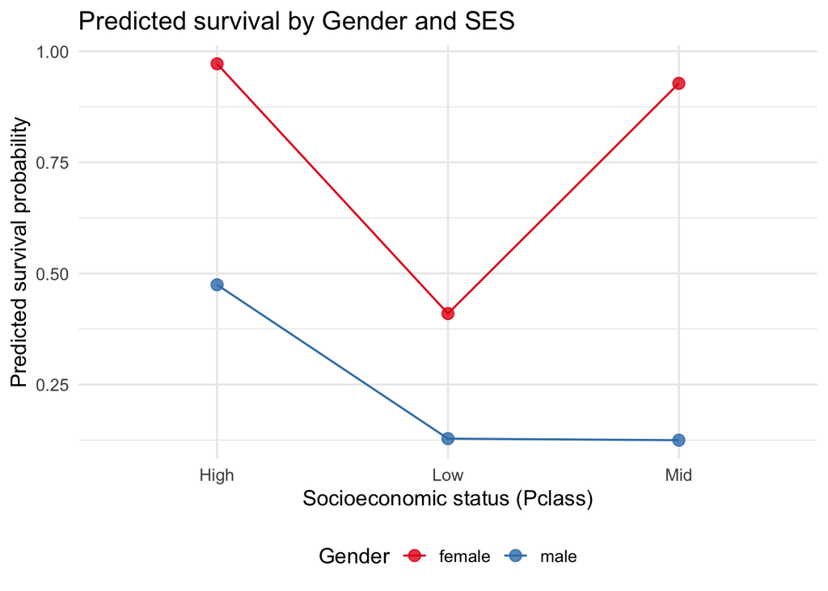

```r
# Visualization: Predicted survival by Sex and SES, averaged over covariates
newdata <- titanic %>%
  summarize(
    Age = mean(Age, na.rm = TRUE),
    FamilyStructure = names(which.max(table(FamilyStructure))),
    Embarked = names(which.max(table(Embarked)))
  )

pred_grid <- expand_grid(Sex = levels(titanic$Sex), SES = levels(titanic$SES)) %>%
  mutate(Age = newdata$Age,
         FamilyStructure = factor(newdata$FamilyStructure, levels = levels(titanic$FamilyStructure)),
         Embarked = factor(newdata$Embarked, levels = levels(titanic$Embarked)))

pred <- pred_grid %>% mutate(
  pred_prob = plogis(predict(fit_full, newdata = pred_grid))
)

ggplot(pred, aes(SES, pred_prob, color = Sex, group = Sex)) +
  geom_point(size = 3) +
  geom_line() +
  scale_color_brewer(palette = "Set1") +
  labs(title = "Predicted survival by Gender and SES",
       x = "Socioeconomic status (Pclass)", y = "Predicted survival probability",
       color = "Gender") +
  theme(legend.position = "bottom")
```